# Wordle, Strings, and Regular Expressions

Bret Larget

This R Markdown document includes contributions from Professor Jessi Kehe.

### Setup details

- You will need the **tidyverse** packages including **stringr** within.
- Be sure to read *R4DS* Chapter 14 for information on **stringr**

## Wordle

- Wordle[^1] is a word-guessing game created by software engineer Josh Wardle, and released to the public during October 2021.
- Subsequently, it exploded in popularity, first by word of mouth, then after mention of it in the *New York Times* in early December tht year.
- Widespread play accelerated after the addition of a feature which allows players to share their results with others using a colored grid of squares.
- There are now millions of daily players around the world. Maybe you are one of them!
- The *New York Times* purchased the game in January, 2022 for more than $1,000,000 and took over the distribution of the game.
- Many variants have been created.
- The rules are straightforward.
- All players try to guess the same five-letter word each day.
- All guesses need to be valid English words.
- Each word is evaluated by a colored response sequence where green means the letter is in the correct place, yellow means the letter is in the solution but is not in the correct location in the guess, and gray means that the letter is not in the solution (or it has already been accounted for if the same letter is colored elsewhere).
- Players get up to six guesses to try to find the solution.
- There are a total of 2,315 possible solutions in the original Wordle lexicon and an additional 10,657 valid guesses which are words, but are either plurals of four-letter words or deemed to be too obscure by Wardle to use as solutions.
- When the *New York Times* took over the management of the game, they made some small modifications to the list of possible solutions.

## Strings and Regular Expressions

- We can play the game using only knowledge of the English language.
- We can also use tools for strings and regular expressions (special strings which match patterns).

### Example

- Here is an example of how using string functions and regular expressions can be used to narrow down the list of possible solutions.
- On one day, the first guess `irate` returned the color sequence `G__YY` where `G` represents green, `Y` represents yellow, and `_` stands for gray.
- The information from this guess and response may be classified in the following manner:
  - there are no letters `r` nor `a` in the solution
  - there is at least one `i`, `t`, and `e`
  - the first letter is an `i`
  - the fourth letter is not a `t`
  - the fifth letter is not an `e`
- We can take the dictionary of possible solutions and filter to retain only words which match this summary of the information.
- The strategy here is to:
  - remove all words that include letters we have eliminated;
  - remove all words missing letters which must be included some number of times;
  - eliminate words which do not have known letters in certain positions or do have letters in a position where those letter cannot be
- This block of code takes the list of solutions and applies these filters from the example.

```r
wrdl_data = read_csv("../../data/wordle_data.csv")
wrdl_solutions = wrdl_data %>%
  filter(solution == TRUE) %>%
  select(word)

w = wrdl_solutions %>%
  ## remove words with eliminated letters
  filter(!str_detect(word, "[ra]")) %>%

  ## retain words with at least one i, t, and e
  filter(str_count(word, 'i') > 0) %>%
  filter(str_count(word, 't') > 0) %>%
  filter(str_count(word, 'e') > 0) %>%

  ## filter based on the pattern
  filter(str_detect(word, "i..[^t][^e]"))

w
```

```
## # A tibble: 3 × 1
##   word
##   <chr>
## 1 inept
## 2 inlet
## 3 islet
```

- Of the 2315 possible solutions, only three are consistent with the observed pattern `G__YY` after the first guess “irate”.
- After this motivation, we spend more time examining foundations of strings and regular expressions.

## Strings

- A *string* is a sequence of characters.
- In R, a string is surrounded by a pair of single quotes or double quotes.

```r
'a string'
```

```
## [1] "a string"
```

```r
"another string"
```

```
## [1] "another string"
```

### Quotes in strings

- A string which contains quotes may be surrounded by the other type.

```r
"A 'string' that contains single quotes"
```

```
## [1] "A 'string' that contains single quotes"
```

```r
'A "string" that contains double quotes'
```

```
## [1] "A \"string\" that contains double quotes"
```

- Alternatively, use a backslash (`\`) before a quote character, or any other special character.

```r
"A \"string\" using backslashes to \"escape\" the double quote characters."
```

```
## [1] "A \"string\" using backslashes to \"escape\" the double quote characters."
```

### Common string functions

- See the Cheat Sheet for a more extensive list.
- All of the string functions begin `str_`.
- We demonstrate a number of common string functions using a small subset of the Wordle data set.
- Many string functions involve a string and a pattern which is a *regular expression*.
- A regular expression is a string where some characters have special meanings.
  - Later this week we will describe regular expressions in more details.
  - When giving examples of various string functions, we will introduce several examples of regular expressions.

```r
set.seed(20230229)
example = slice_sample(wrdl_solutions, n = 10) %>%
  arrange(word)

example
```

```
## # A tibble: 10 × 1
##    word
##    <chr>
##  1 awash
##  2 comet
##  3 crone
##  4 finch
##  5 forum
##  6 liege
##  7 paler
##  8 plain
##  9 torso
## 10 video
```

### Detect matches

- A pattern is a string which holds a *regular expression* that can match strings with particular patterns
- The simplest pattern is an exact match with the string
- Later, we describe many ways to build regular expressions

#### Example functions

- `str_detect(string, pattern)` — detect a pattern in a string
- `str_count(string, pattern)` — count the number of times a string contains a pattern

> Which example words contain the letter “a”?

```r
example %>%
  filter(str_detect(word, "a"))
```

```
## # A tibble: 3 × 1
##   word
##   <chr>
## 1 awash
## 2 paler
## 3 plain
```

> Which example words begin with the letter “a”? The symbol `^` at the start of a regular expression represents the beginning of a string.

```r
example %>%
  filter(str_detect(word, "^a"))
```

```
## # A tibble: 1 × 1
##   word
##   <chr>
## 1 awash
```

> Which example words end with a vowel? The symbol `$` at the end of a regular expression represents the end of a string. The pattern `[aeiouy]` matches any one of the letters between the brackets.

```r
example %>%
  filter(str_detect(word, "[aeiouy]$"))
```

```
## # A tibble: 4 × 1
##   word
##   <chr>
## 1 crone
## 2 liege
## 3 torso
## 4 video
```

> Count the number of vowels (here, one of a, e, i, o, u) in each word. (It is more complicated to say when y is a consonent and when it is a vowel.)

```r
example %>%
  mutate(n = str_count(word, "[aeiou]"))
```

```
## # A tibble: 10 × 2
##    word      n
##    <chr> <int>
##  1 awash     2
##  2 comet     2
##  3 crone     2
##  4 finch     1
##  5 forum     2
##  6 liege     3
##  7 paler     2
##  8 plain     2
##  9 torso     2
## 10 video     3
```

### Subsets

- A subset is part of the string
- When selecting by position, positive numbers count from the beginning, negative count from th end.

#### Example functions

- `str_sub(string, start, end)` — extract a subset by position
- `str_extract(string, pattern)` — extract first match of pattern, `NA` if no match

> Create variables with several substrings

```r
example %>%
  mutate(first = str_sub(word, 1, 1),
         first_three = str_sub(word, 1, 3),
         last = str_sub(word, -1, -1),
         last_two = str_sub(word, -2, -1),
         not_first = str_sub(word, 2, -1),
         first_vowel = str_extract(word, "[aeiou]"))
```

```
## # A tibble: 10 × 7
##    word  first first_three last  last_two not_first first_vowel
##    <chr> <chr> <chr>       <chr> <chr>    <chr>     <chr>
##  1 awash a     awa         h     sh       wash      a
##  2 comet c     com         t     et       omet      o
##  3 crone c     cro         e     ne       rone      o
##  4 finch f     fin         h     ch       inch      i
##  5 forum f     for         m     um       orum      o
##  6 liege l     lie         e     ge       iege      i
##  7 paler p     pal         r     er       aler      a
##  8 plain p     pla         n     in       lain      a
##  9 torso t     tor         o     so       orso      o
## 10 video v     vid         o     eo       ideo      i
```

> Extract several patterns: `.` matches any character

```r
example %>%
  mutate(first = str_extract(word, "^."),
         first_three = str_extract(word, "^..."),
         also_first_three = str_extract(word, "^.{3}"),
         last = str_extract(word, ".$"),
         last_two = str_extract(word, "..$"))
```

```
## # A tibble: 10 × 6
##    word  first first_three also_first_three last  last_two
##    <chr> <chr> <chr>       <chr>            <chr> <chr>
##  1 awash a     awa         awa              h     sh
##  2 comet c     com         com              t     et
##  3 crone c     cro         cro              e     ne
##  4 finch f     fin         fin              h     ch
##  5 forum f     for         for              m     um
##  6 liege l     lie         lie              e     ge
##  7 paler p     pal         pal              r     er
##  8 plain p     pla         pla              n     in
##  9 torso t     tor         tor              o     so
## 10 video v     vid         vid              o     eo
```

### Length

- The *length* of a string is the number of characters in it.

#### Example functions

- `str_length(string)` — length of the string
- `str_pad(string, width, side, pad = " ")` — pad strings to a constant width

> Count lengths

```r
example %>%
  mutate(n = str_length(word))
```

```
## # A tibble: 10 × 2
##    word      n
##    <chr> <int>
##  1 awash     5
##  2 comet     5
##  3 crone     5
##  4 finch     5
##  5 forum     5
##  6 liege     5
##  7 paler     5
##  8 plain     5
##  9 torso     5
## 10 video     5
```

> Add spaces to pad to a length of seven letters

```r
example %>%
  mutate(add_to_right = str_pad(word, 7, side = "right"),
         add_to_left = str_pad(word, 7, side = "left"),
         add_to_both = str_pad(word, 7, side = "both"))
```

```
## # A tibble: 10 × 4
##    word  add_to_right add_to_left add_to_both
##    <chr> <chr>        <chr>       <chr>
##  1 awash "awash  "    "  awash"   " awash "
##  2 comet "comet  "    "  comet"   " comet "
##  3 crone "crone  "    "  crone"   " crone "
##  4 finch "finch  "    "  finch"   " finch "
##  5 forum "forum  "    "  forum"   " forum "
##  6 liege "liege  "    "  liege"   " liege "
##  7 paler "paler  "    "  paler"   " paler "
##  8 plain "plain  "    "  plain"   " plain "
##  9 torso "torso  "    "  torso"   " torso "
## 10 video "video  "    "  video"   " video "
```

### Mutate

- Modify strings

#### Example functions

- `str_sub(string, start, end) = replacement_string` — replace a subset by position
- `str_replace(string, pattern, replacement)` — replace first match with replacement
- `str_to_lower(string)` — change all letters to lower case
- `str_to_upper(string)` — change all letters to upper case

> Replace letters in positions 2–4 with a single “X”

```r
## create a string which will be modified
x = example$word
str_sub(x, 2, 4) = "X"; x
```

```
##  [1] "aXh" "cXt" "cXe" "fXh" "fXm" "lXe" "pXr" "pXn" "tXo" "vXo"
```

> Replace the first vowel with an X; make all caps

```r
example %>%
  mutate(x = str_replace(word, "[aeiou]", "X"),
         all_caps = str_to_upper(word))
```

```
## # A tibble: 10 × 3
##    word  x     all_caps
##    <chr> <chr> <chr>
##  1 awash Xwash AWASH
##  2 comet cXmet COMET
##  3 crone crXne CRONE
##  4 finch fXnch FINCH
##  5 forum fXrum FORUM
##  6 liege lXege LIEGE
##  7 paler pXler PALER
##  8 plain plXin PLAIN
##  9 torso tXrso TORSO
## 10 video vXdeo VIDEO
```

### Join and split

- Combine strings or divide them

#### Example functions

- `str_c(..., sep = "")` — combine multiple strings into one
- `str_split(string, pattern)`

> Create a new word with the first and last letters repeated

```r
example %>%
  mutate(new_word = str_c(str_sub(word,1,1), word, str_sub(word,-1,-1)))
```

```
## # A tibble: 10 × 2
##    word  new_word
##    <chr> <chr>
##  1 awash aawashh
##  2 comet ccomett
##  3 crone ccronee
##  4 finch ffinchh
##  5 forum fforumm
##  6 liege lliegee
##  7 paler ppalerr
##  8 plain pplainn
##  9 torso ttorsoo
## 10 video vvideoo
```

> Split each word by its vowels and return a list of character vectors

```r
## returns a list for each word
example %>%
  pull(word) %>%
  str_split("[aeiou]")
```

```
## [[1]]
## [1] ""   "w"  "sh"
##
## [[2]]
## [1] "c" "m" "t"
##
## [[3]]
## [1] "cr" "n"  ""
##
## [[4]]
## [1] "f"   "nch"
##
## [[5]]
## [1] "f" "r" "m"
##
## [[6]]
## [1] "l" ""  "g" ""
##
## [[7]]
## [1] "p" "l" "r"
##
## [[8]]
## [1] "pl" ""   "n"
##
## [[9]]
## [1] "t"  "rs" ""
##
## [[10]]
## [1] "v" "d" ""  ""
```

## Regular Expressions

- A *regular expression* is a sequence of characters that defines a pattern which may match a string or part of a string
- Most characters match only their matching character:
  - `a` matches only `a`, `A` matches only `A`
  - `,` and `;` match the corresponding punctuation marks
  - Usually, a digit such as `1` or `2` matches only the corresponding digit
    - An exception is when preceded by a backslash, `\1`
- There are many special characters that take on special meaning in a regular expression
- When you want the literal special character, you need to precede it with a backslash, `\`.
- This includes the symbol `\` itself.

### Representing Regular Expressions as Strings in R

- The regular expression `^.{3}` matches the first three characters of a string.
- Inside of R, we store the regular expression as a string, `"^.{3}"`.
- For most regular expressions, this is straightforward.
- However, the character `\`:
  - means something special in a string in R; and
  - means something special in a regular expression
- Later, we will show examples of how we need to treat regular expressions which contain `\` carefully when represented in a string.

### Examples

#### Alternates

- `|` — *or*, match exactly one of the possibilities: can separate more than two choices
- `[]` — *one of*, match one of the characters between the brackets
- `[^]`— *anything but*, match anything *not* between `[^` and `]`
- ranges — examples: `[a-d]`, `[0-5]`, `[a-zA-Z]`

> Which example words contain an ‘a’ or an ‘i’ or the letter combo ‘rs’?

```r
example %>%
  filter(str_detect(word, "a|i|rs"))
```

```
## # A tibble: 7 × 1
##   word
##   <chr>
## 1 awash
## 2 finch
## 3 liege
## 4 paler
## 5 plain
## 6 torso
## 7 video
```

> Which example words contain at least one letter of “bucky”?

```r
example %>%
  filter(str_detect(word, "[bucky]"))
```

```
## # A tibble: 4 × 1
##   word
##   <chr>
## 1 comet
## 2 crone
## 3 finch
## 4 forum
```

> Find the first character in the example words which is not a letter from the word “bucky”? Note that `^` here means NOT instead of the start of the string.

```r
example %>%
  mutate(not_bucky = str_extract(word, "[^bucky]"))
```

```
## # A tibble: 10 × 2
##    word  not_bucky
##    <chr> <chr>
##  1 awash a
##  2 comet o
##  3 crone r
##  4 finch f
##  5 forum f
##  6 liege l
##  7 paler p
##  8 plain p
##  9 torso t
## 10 video v
```

> Find the first letter from `c` through `g` in each word. Note, the value is NA if there is no match to the pattern

```r
example %>%
  mutate(first_c_through_g = str_extract(word, "[c-g]"))
```

```
## # A tibble: 10 × 2
##    word  first_c_through_g
##    <chr> <chr>
##  1 awash <NA>
##  2 comet c
##  3 crone c
##  4 finch f
##  5 forum f
##  6 liege e
##  7 paler e
##  8 plain <NA>
##  9 torso <NA>
## 10 video d
```

#### Anchors

- `^` — the start of the string
- `$` — the end of the string
- We have seen these many times already.

#### Quantifiers

- How often does the previous character/group need to appear?
- `?` — 0 or 1
- `*` — 0 or more
- `+` — 1 or more
- `{n}` — exactly `n` times
- `{n,}` — `n` or more
- `{m,n}` — from `m` to `n` times

> Extract a `c` followed by 0 or 1 letters `h`

```r
example %>%
  mutate(x = str_extract(word, "ch?"))
```

```
## # A tibble: 10 × 2
##    word  x
##    <chr> <chr>
##  1 awash <NA>
##  2 comet c
##  3 crone c
##  4 finch ch
##  5 forum <NA>
##  6 liege <NA>
##  7 paler <NA>
##  8 plain <NA>
##  9 torso <NA>
## 10 video <NA>
```

> Extract the letter “l” followed by 0 or more vowels

```r
example %>%
  mutate(x = str_extract(word, "l[aeiou]*"))
```

```
## # A tibble: 10 × 2
##    word  x
##    <chr> <chr>
##  1 awash <NA>
##  2 comet <NA>
##  3 crone <NA>
##  4 finch <NA>
##  5 forum <NA>
##  6 liege lie
##  7 paler le
##  8 plain lai
##  9 torso <NA>
## 10 video <NA>
```

> Extract one or more consonents followed by the letter ‘o’

```r
example %>%
  mutate(x = str_extract(word, "[^aeiou]+o"))
```

```
## # A tibble: 10 × 2
##    word  x
##    <chr> <chr>
##  1 awash <NA>
##  2 comet co
##  3 crone cro
##  4 finch <NA>
##  5 forum fo
##  6 liege <NA>
##  7 paler <NA>
##  8 plain <NA>
##  9 torso to
## 10 video <NA>
```

```r
## Notice in the word "torso", the first instance is found
```

> Extract various parts of the words

```r
example %>%
  mutate(first_three = str_extract(word, ".{3}"),
         one_or_two_vowels = str_extract(word, "[aeiou]{1,2}"),
         two_or_more_consonents_at_end = str_extract(word,"[^aeiou]{2,}$"))
```

```
## # A tibble: 10 × 4
##    word  first_three one_or_two_vowels two_or_more_consonents_at_end
##    <chr> <chr>       <chr>             <chr>
##  1 awash awa         a                 sh
##  2 comet com         o                 <NA>
##  3 crone cro         o                 <NA>
##  4 finch fin         i                 nch
##  5 forum for         o                 <NA>
##  6 liege lie         ie                <NA>
##  7 paler pal         a                 <NA>
##  8 plain pla         ai                <NA>
##  9 torso tor         o                 <NA>
## 10 video vid         i                 <NA>
```

### Special collections

- `[:space:]` — space, tab, newline
- `[:blank:]` — space and tab
- `[:punct:]` — a collection of punctuation characters
- `[:symbol:]` — a collection of symbols
- `[:digit:]` — a digit
- `[:lower:]` — same as `[a-z]`, a lower-case letter
- `[:upper:]` — same as `[A-Z]`, an upper-case letter
- `[:alpha:]` — same as `[a-zA-Z]`, `[:lower:]|[:upper]`
- `[:alnum:]` — letter or number, `[:alpha:]|[:digit:]`
- `[:graph:]` — punctuation, symbols, digits, letters
  - same as `[:punct:]|[:symbol:]|[:alnum:]`
- `.` — matches any single character except for a newline

#### Others

- See the cheat sheet for others:
  - Peek ahead and behind
  - Groups

## Regular expression representations in R

- Each regular expression is represented as a string in R
- Most regular expressions are simply the string of the regular with no changes
  - the regular expression `abc+` is represented as the string `"abc+"`
- However, regular expressions that include a backslash, `\`, need to duplicate the `\` in the string representation as `\` means something special inside a string.
  - `\n` is the new line character in a string
  - `\t` is the tab character in a string
  - and there are more examples

### Special Characters

- There are a few characters with special meaning in a regular expression.
- Examples we have seen include `^`, `$`, `\`, `+`, `[`, `]`, `{`, `}`, `-`, `.`, and `*`.
- If we want to match a literal one of these characters in a regular expression, we precede the character with the backslash `\`.
  - This includes the backslash characters itself.
- But as `\` carries special meaning in a string in R, each `\` needs to be preceded by `\` in the string representation of the regular expression.
  - A consequence is that a literal `\` is represented by the string `"\\\\"` in the string representation of a regular expression with a literal `\`.

#### Examples

- The regular expression `a+`, which matches one or more consecutive `a`s, has the string representation `"a+"`
- The regular expression `a\+`, which matches an `a` followed by a literal `+`, has the string representation `"a\\+"`
- The regular expression `\\`, which matches a literal `\`, has the string representation `"\\\\"` as each `\` in the regular expression requires `\\` in the string representation.

## Color name examples

- We create a simple data frame consisting of the built in names in R.
  - `colors()` creates a vector of color names
  - `row_number()` creates a sequence from 1 to the number of rows of the data frame
  - the argument `.before = colors` places the variable `index` before `colors`.

```r
df_colors = tibble(colors = colors()) %>%
  mutate(index = row_number(), .before = colors)

print(df_colors)
```

```
## # A tibble: 657 × 2
##    index colors
##    <int> <chr>
##  1     1 white
##  2     2 aliceblue
##  3     3 antiquewhite
##  4     4 antiquewhite1
##  5     5 antiquewhite2
##  6     6 antiquewhite3
##  7     7 antiquewhite4
##  8     8 aquamarine
##  9     9 aquamarine1
## 10    10 aquamarine2
## # … with 647 more rows
```

## Problems

> Find the shortest and longest color names
- It would be nice to have a function which returns the length of a string.
- Consult the **stringr** cheat sheet:
  - Aha! Use `str_length()` to find the length of each string
- Then use `slice_max()` or `slice_min()` to identify the extremes

### Live Coding

```r
## shortest

## longest
```

#### Prepared Solution

```r
## Add the string length
df1 = df_colors %>%
  mutate(length = str_length(colors))

## Longest
longest = df1 %>%
  slice_max(n = 1, order_by = length)

longest
```

```
## # A tibble: 1 × 3
##   index colors               length
##   <int> <chr>                 <int>
## 1   415 lightgoldenrodyellow     20
```

```r
## Shortest
shortest = df1 %>%
  slice_min(n = 1, order_by = length)

shortest
```

```
## # A tibble: 2 × 3
##   index colors length
##   <int> <chr>   <int>
## 1   552 red         3
## 2   620 tan         3
```

- The longest color name is lightgoldenrodyellow with a length of 20 characters.
- The shortest color names are red and tan, each with a length of 3.

> Make a bar plot of the string lengths
- Note use of `scale_x_continuous()` to change the default breaks and labels in the plot.

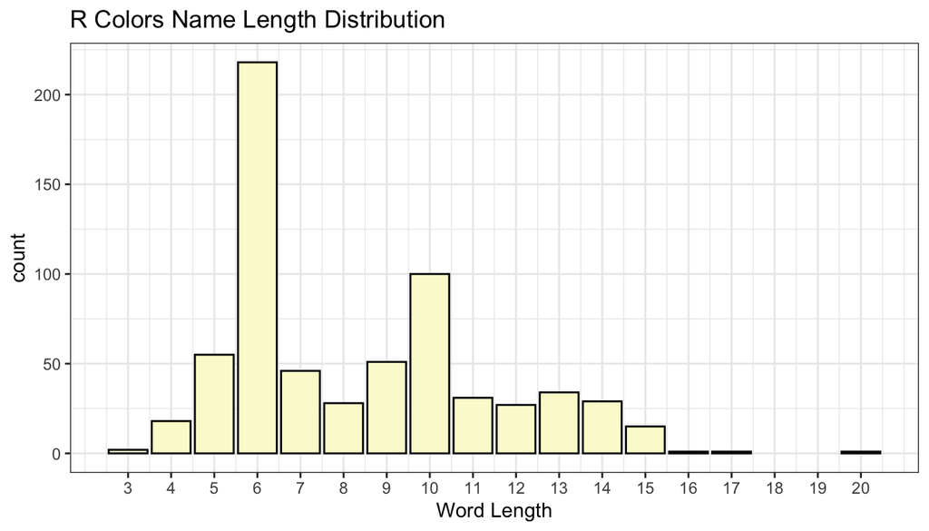

```r
ggplot(df1, aes(x=length)) +
  geom_bar(fill = longest$colors, color="black") +
  xlab("Word Length") +
  scale_x_continuous(labels = 3:20, breaks = 3:20) +
  ggtitle("R Colors Name Length Distribution") +
  theme_bw()
```

> Find the color names of length 8. Report the number, and the first and last color name (alphabetically).

### Live Coding

#### Prepared Solution

```r
df2 = df_colors %>%
  filter(str_length(colors) == 8) %>%
  arrange(colors)

df2 %>%
  summarize(n = n(),
            first = min(colors),
            last = max(colors))
```

```
## # A tibble: 1 × 3
##       n first    last
##   <int> <chr>    <chr>
## 1    28 cornsilk thistle4
```

```r
df2 %>%
  print(n = Inf)
```

```
## # A tibble: 28 × 2
##    index colors
##    <int> <chr>
##  1    63 cornsilk
##  2    73 darkblue
##  3    74 darkcyan
##  4    80 darkgray
##  5    82 darkgrey
##  6   116 deeppink
##  7   362 honeydew
##  8   368 hotpink1
##  9   369 hotpink2
## 10   370 hotpink3
## 11   371 hotpink4
## 12   387 lavender
```

[output cut: 16 more lines]

> How many color names begin and end with the same letter? Report the number and the first and last alphabetically.

### Prepared Solutions

#### Solution 1

- One approach is to create new variables with the first and last letters of each column and then filter for cases where these are the same.
- Is there a function to grab part of a string? Check the cheat sheet:
- Aha! There are several potentially useful functions.
- `str_sub(string, start, end)` returns the sub string from `start` to `end`
  - Use negatives to count from the end.
  - Can also be used to assign values by position
- `str_extract(string, pattern)` returns the first substring to match the regular expression encoded in `pattern`.

```r
## Solution using str_sub()
## Positive start and end count from the start
## Negative count from the end
df3a = df_colors %>%
  mutate(first = str_sub(colors,1,1),
         last = str_sub(colors,-1,-1)) %>%
  filter(first == last)
df3a
```

```
## # A tibble: 6 × 4
##   index colors        first last
##   <int> <chr>         <chr> <chr>
## 1    75 darkgoldenrod d     d
## 2    95 darkorchid    d     d
## 3   100 darkred       d     d
## 4   404 lightcoral    l     l
## 5   478 mintcream     m     m
## 6   529 papayawhip    p     p
```

```r
df3a %>%
  summarize(n=n(), first = min(colors), last = max(colors))
```

```
## # A tibble: 1 × 3
##       n first         last
##   <int> <chr>         <chr>
## 1     6 darkgoldenrod papayawhip
```

#### Solution 2

- Next, use regular expressions and `str_extract()`.
- Note the special characters:
  - `^` matches the start of the string
  - `$` matches the end of the string
  - `.` matches any single character (except for end of line)

```r
## Solution using str_extract()
df3b = df_colors %>%
  mutate(first = str_extract(colors, "^."),
         last = str_extract(colors, ".$")) %>%
  filter(first == last)

df3b
```

```
## # A tibble: 6 × 4
##   index colors        first last
##   <int> <chr>         <chr> <chr>
## 1    75 darkgoldenrod d     d
## 2    95 darkorchid    d     d
## 3   100 darkred       d     d
## 4   404 lightcoral    l     l
## 5   478 mintcream     m     m
## 6   529 papayawhip    p     p
```

```r
df3b %>%
  summarize(n=n(), first = min(colors), last = max(colors))
```

```
## # A tibble: 1 × 3
##       n first         last
##   <int> <chr>         <chr>
## 1     6 darkgoldenrod papayawhip
```

#### Solution 3

- We could have accomplished the same thing without creating the extra columns
- However, it can be helpful to create the columns to make sure the code is doing what you think it is doing

```r
df_colors %>%
  filter( str_extract(colors, "^.") == str_extract(colors, ".$") )
```

```
## # A tibble: 6 × 2
##   index colors
##   <int> <chr>
## 1    75 darkgoldenrod
## 2    95 darkorchid
## 3   100 darkred
## 4   404 lightcoral
## 5   478 mintcream
## 6   529 papayawhip
```

#### Solution 4

- Another fancy solution uses the group operator, `()`.
  - Each part of a regular expression surrounded by parentheses is saved and labeled for further use.
    - The first part may be recalled with `\1`, the second with `\2`, and so on.
    - When representing `\` in a regular expression as a string in R, recall it needs to be “escaped” with a leading `\`
- We use `str_detect()` to detect when the color name matches a pattern where the first character is a letter that is also used as the last character.
- Note the use of the special regular expression syntax `[:alpha:]` which matches letters of the alphabet.
  - Alternatives are:
    - `[:lower:]` or `[a-z]` for lowercase letters
    - `[:upper:]` or `[A-Z]` for uppercase letters
    - `[a-zA-Z]` for lowercase or uppercase letters
- The character `.` matches any character.
- The character `*` repeats the previous pattern 0 or more times.
- Put all together, the regular expression `^([:alpha:]).*\1$` matches:
  - a letter at the beginning of the string
  - then any set of characters of length 0 or more
  - followed by the same letter as at the start of the string at the end
- We need to replace `\` with `\\` in the string representation of the regular expression.

```r
df3c = df_colors %>%
  filter(str_detect(colors, "^([:alpha:]).*\\1$"))

df3c
```

```
## # A tibble: 6 × 2
##   index colors
##   <int> <chr>
## 1    75 darkgoldenrod
## 2    95 darkorchid
## 3   100 darkred
## 4   404 lightcoral
## 5   478 mintcream
## 6   529 papayawhip
```

> Find all color names that begin with a letter from “aeiou” and end with a letter from “aeiouy”

### Live Coding

#### Solution

- Regular expression special symbols:
  - `^` is the beginning of the string
  - `$` is the end of the string
  - `.` is any character (except a newline)
  - `*` means repeat 0 or more times
  - `[...]` matches any character from between the `[` and the `]`

```r
df4 = df_colors %>%
  filter(str_detect(colors, "^[aeiou].*[aeiouy]$"))
df4
```

```
## # A tibble: 7 × 2
##   index colors
##   <int> <chr>
## 1     2 aliceblue
## 2     3 antiquewhite
## 3     8 aquamarine
## 4    13 azure
## 5   377 ivory
## 6   492 oldlace
## 7   498 orange
```

> Find all colors names which begin with a vowel, end with a consonant, have no digits in the name, and have between 4 and 10 total characters

### Live Coding

#### Prepared Solution

- Regular expression `[:digit:]` stands for a digit.
  - Alternatives are `\d` or `[0-9]`
- In an R string, need to double the `\` in order to represent the literal `\`.
- A `^` right after `[` negates the matches between the `[` and the `]`
- `{n}` repeats the previous pattern `n` times
- `{m,n}` repeats the previous pattern from `m` to `n` times

```r
df5 = df_colors %>%
  filter(!str_detect(colors,"[:digit:]")) %>% # no digit
  filter(str_detect(colors, "^[aeiou].{2,8}[^aeiouy]$")) %>%
  mutate(length = str_length(colors)) # added to check the length
df5
```

```
## # A tibble: 4 × 3
##   index colors    length
##   <int> <chr>      <int>
## 1   372 indianred      9
## 2   493 olivedrab      9
## 3   503 orangered      9
## 4   508 orchid         6
```

> Find all color names that repeat a letter twice in a row.

### Live Coding

#### Prepared Solution

- Surrounding a pattern with `()` changes the order of preference and forms a group.
- Whichever pattern matches a group may be referred to by `\x` where `x` is the number of the group
  - For example, `([a-e])\1` will match double letters from a through e.
  - But in the string representation in R, we need to precede `\` by another `\` to indicate we mean the literal `\`. So, `"([a-e])\\1"`

```r
## Lecture
df6 = df_colors %>%
  filter(str_detect(colors, "([:alpha:])\\1"))

df6
```

```
## # A tibble: 104 × 2
##    index colors
##    <int> <chr>
##  1    37 burlywood
##  2    38 burlywood1
##  3    39 burlywood2
##  4    40 burlywood3
##  5    41 burlywood4
##  6    81 darkgreen
##  7    83 darkkhaki
##  8    85 darkolivegreen
##  9    86 darkolivegreen1
## 10    87 darkolivegreen2
## # … with 94 more rows
```

> Find all color names which contain the substrings “red”, “blue”, or “green”

### Live Coding

#### Prepared Solution

- separate alternative patterns with a `|`

```r
## Lecture
df7 = df_colors %>%
  filter(str_detect(colors, "red|blue|green"))

df7
```

```
## # A tibble: 133 × 2
##    index colors
##    <int> <chr>
##  1     2 aliceblue
##  2    26 blue
##  3    27 blue1
##  4    28 blue2
##  5    29 blue3
##  6    30 blue4
##  7    31 blueviolet
##  8    42 cadetblue
##  9    43 cadetblue1
## 10    44 cadetblue2
## # … with 123 more rows
```

## Wordle Examples (if time permits)

### Read the Wordle Data

```r
wrdl_data = read_csv("../../data/wordle_data.csv")

wrdl_solutions = wrdl_data %>%
  filter(solution == TRUE) %>%
  select(word)
```

- A number of questions about Wordle would be easier to answer if we had the data in a long format with one letter per row and variables to indicate the word it came from and the position of the letter.
- This block of code does so using `str_sub()` to extract the letters by position and then `pivot_longer()` to get the table.
- A more general solution would not depend on all of the words having five letters.

```r
wrdl_long = wrdl_solutions %>%
  ## add an index variable
  mutate(index = row_number(), .before = word) %>%

  ## probably a better way to do this with iteration!
  ## use digits as column names so they can be made
  ##   into position values after reshaping the data
  mutate(`1` = str_sub(word,1,1)) %>%
  mutate(`2` = str_sub(word,2,2)) %>%
  mutate(`3` = str_sub(word,3,3)) %>%
  mutate(`4` = str_sub(word,4,4)) %>%
  mutate(`5` = str_sub(word,5,5)) %>%

  ## now reshape
  pivot_longer(`1`:`5`,
               names_to = "position",
               values_to = "letter") %>%
  ## change position values from strings to numbers
  mutate(position = as.integer(position))
```

### Questions

> How often is each letter used in the set of solutions?

#### Prepared Solution

```r
q1 = wrdl_long %>%
  count(letter) %>%
  arrange(desc(n))

q1 %>%
  print(n = Inf)
```

```
## # A tibble: 26 × 2
##    letter     n
##    <chr>  <int>
##  1 e       1233
##  2 a        979
##  3 r        899
##  4 o        754
##  5 t        729
##  6 l        719
##  7 i        671
##  8 s        669
##  9 n        575
## 10 c        477
## 11 u        467
## 12 y        425
## 13 d        393
## 14 h        389
## 15 p        367
## 16 m        316
## 17 g        311
## 18 b        281
## 19 f        230
## 20 k        210
## 21 w        195
## 22 v        153
## 23 z         40
## 24 x         37
## 25 q         29
## 26 j         27
```

> Graph the results

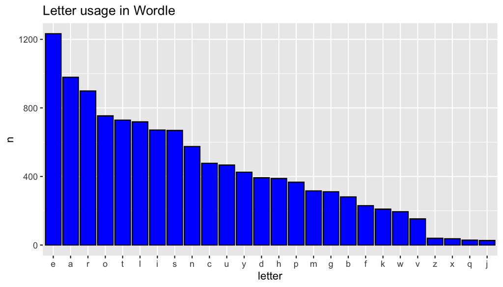

```r
q1 %>%
  mutate(letter = reorder(letter,-n)) %>%
ggplot(aes(x = letter, y = n)) +
  geom_col(color = "black", fill = "blue") +
  ggtitle("Letter usage in Wordle")
```

> How many times does each letter appear in each position?

#### Prepared Solution

```r
pos_counts = wrdl_long %>%
  count(letter, position) %>%
  arrange(position, desc(n))
```

- Use `pivot_wider()` for a summary table, formatted nicely.

```r
pos_counts_table = pos_counts %>%
  pivot_wider(names_from = position,
              values_from = n,
              values_fill = 0)

pos_counts_table %>%
  kable() %>%
  kable_styling(position = "left", full_width = FALSE,
                bootstrap_options = c("striped"))
```

| letter | 1 | 2 | 3 | 4 | 5 |
| --- | --- | --- | --- | --- | --- |
| s | 366 | 16 | 80 | 171 | 36 |
| c | 198 | 40 | 56 | 152 | 31 |
| b | 173 | 16 | 57 | 24 | 11 |
| t | 149 | 77 | 111 | 139 | 253 |
| p | 142 | 61 | 58 | 50 | 56 |
| a | 141 | 304 | 307 | 163 | 64 |
| f | 136 | 8 | 25 | 35 | 26 |
| g | 115 | 12 | 67 | 76 | 41 |
| d | 111 | 20 | 75 | 69 | 118 |
| m | 107 | 38 | 61 | 68 | 42 |
| r | 105 | 267 | 163 | 152 | 212 |
| l | 88 | 201 | 112 | 162 | 156 |
| w | 83 | 44 | 26 | 25 | 17 |
| e | 72 | 242 | 177 | 318 | 424 |
| h | 69 | 144 | 9 | 28 | 139 |
| v | 43 | 15 | 49 | 46 | 0 |
| o | 41 | 279 | 244 | 132 | 58 |
| n | 37 | 87 | 139 | 182 | 130 |
| i | 34 | 202 | 266 | 158 | 11 |
| u | 33 | 186 | 165 | 82 | 1 |
| q | 23 | 5 | 1 | 0 | 0 |
| j | 20 | 2 | 3 | 2 | 0 |
| k | 20 | 10 | 12 | 55 | 113 |
| y | 6 | 23 | 29 | 3 | 364 |
| z | 3 | 2 | 11 | 20 | 4 |
| x | 0 | 14 | 12 | 3 | 8 |

> Which Wordle solutions have four vowels?

#### Prepared Solutions

```r
wrdl_solutions %>%
  mutate(n_vowels = str_count(word, "[aeiou]")) %>%
  filter(n_vowels == 4)
```

```
## # A tibble: 3 × 2
##   word  n_vowels
##   <chr>    <int>
## 1 audio        4
## 2 eerie        4
## 3 queue        4
```

> Which Wordle solutions contain the same letter three or more times?

#### Prepared Solutions

```r
wrdl_long %>%
  count(word, letter) %>%
  filter(n >= 3) %>%
  select(-letter)
```

```
## # A tibble: 20 × 2
##    word      n
##    <chr> <int>
##  1 bobby     3
##  2 daddy     3
##  3 eerie     3
##  4 emcee     3
##  5 error     3
##  6 fluff     3
##  7 geese     3
##  8 mamma     3
##  9 mammy     3
## 10 melee     3
## 11 mummy     3
## 12 nanny     3
## 13 ninny     3
## 14 poppy     3
## 15 puppy     3
## 16 rarer     3
## 17 sassy     3
## 18 sissy     3
## 19 tatty     3
## 20 tepee     3
```

### Extensions

- There are many more ways to use tools of data science using R to explore Wordle:
  - Write code to simulate playing
  - Write a function that takes results from previous guesses and returns a list of remaining solutions
  - Examine strategies for best words (by different criteria)
- Maybe some groups will explore these ideas with a project.
[^1]: https://www.powerlanguage.co.uk/wordle/